# Relatório 04

Gustavo Cardoso

01/05/2025

# 1 Objetivo

Avaliar o efeito de quatro tipos de aditivos impermeabilizantes (Controle, Acrílico, Silicone e Asfáltico) sobre a absorção de água (%) de blocos de concreto moldados em laboratório, utilizando um Delineamento Inteiramente Casualizado (DIC) com 5 repetições por tratamento.

# 2 Apresentação do relatório

Este relatório apresenta a análise estatística de um experimento conduzido em laboratório para avaliar o efeito de diferentes aditivos impermeabilizantes na absorção de água (%) de blocos de concreto. Utilizou-se um Delineamento Inteiramente Casualizado (DIC) com quatro tratamentos (tipos de aditivo) e cinco repetições cada.

A análise foi realizada com base nos pressupostos da ANOVA, seguida por testes de normalidade dos resíduos, homogeneidade de variâncias e comparação múltipla de médias (Tukey). As informações são apresentadas de forma descritiva, visual e inferencial, com apoio de gráficos, tabelas e código R, buscando uma compreensão clara dos efeitos dos tratamentos sobre a variável de interesse.

```r
# Carregar pacotes
library(gt)
# Dados do experimento
aditivo <- factor(rep(c("Controle", "Acrílico", "Silicone", "Asfáltico"), each = 5))
absorcao <- c(
  12.276, 12.408, 13.123, 12.528, 12.552,
  10.058, 9.430, 8.567, 8.857, 8.977,
  8.167, 7.908, 7.920, 7.833, 7.633,
  9.215, 8.699, 7.713, 8.781, 8.311
)

# Criar data frame
experimento <- data.frame(aditivo, absorcao)

# Exibir tabela formatada
experimento |>
  gt() |>
  tab_style(
    style = list(cell_text(weight = "bold", color = "white"),
                 cell_fill(color = "#0073e6")),
    locations = cells_column_labels()
  ) |>
  tab_style(
    style = cell_text(align = "center"),
    locations = cells_body(columns = everything())
  ) |>
  data_color(
    columns = everything(),
    rows = seq(1, nrow(experimento), 2),
    colors = "#f2f2f2"
  ) |>
  data_color(
    columns = everything(),
    rows = seq(2, nrow(experimento), 2),
    colors = "#e6f7ff"
  )
```

| aditivo | absorcao |
| --- | --- |
| Controle | 12.276 |
| Controle | 12.408 |
| Controle | 13.123 |
| Controle | 12.528 |
| Controle | 12.552 |
| Acrílico | 10.058 |
| Acrílico | 9.430 |
| Acrílico | 8.567 |
| Acrílico | 8.857 |
| Acrílico | 8.977 |
| Silicone | 8.167 |
| Silicone | 7.908 |
| Silicone | 7.920 |
| Silicone | 7.833 |
| Silicone | 7.633 |
| Asfáltico | 9.215 |
| Asfáltico | 8.699 |
| Asfáltico | 7.713 |
| Asfáltico | 8.781 |
| Asfáltico | 8.311 |

```r
# Estatísticas por grupo
aggregate(absorcao ~ aditivo, data = experimento,
          FUN = function(x) c(média = mean(x), desvio = sd(x), CV = sd(x)/mean(x)*100))
```

```
##     aditivo absorcao.média absorcao.desvio absorcao.CV
## 1  Acrílico      9.1778000       0.5819508   6.3408526
## 2 Asfáltico      8.5438000       0.5646425   6.6087987
## 3  Controle     12.5774000       0.3241540   2.5772733
## 4  Silicone      7.8922000       0.1918507   2.4308903
```

```r
# Modelo de ANOVA
modelo <- aov(absorcao ~ aditivo, data = experimento)

# Tabela da ANOVA
summary(modelo)
```

```
##             Df Sum Sq Mean Sq F value   Pr(>F)
## aditivo      3  65.32   21.77     109 7.35e-11 ***
## Residuals   16   3.20    0.20
## ---
## Signif. codes:  0 '***' 0.001 '**' 0.01 '*' 0.05 '.' 0.1 ' ' 1
```

```r
# Teste de normalidade dos resíduos
shapiro.test(resid(modelo))
```

```
##
##  Shapiro-Wilk normality test
##
## data:  resid(modelo)
## W = 0.97611, p-value = 0.8746
```

```r
# Teste de homogeneidade de variâncias
bartlett.test(absorcao ~ aditivo, data = experimento)
```

```
##
##  Bartlett test of homogeneity of variances
##
## data:  absorcao by aditivo
## Bartlett's K-squared = 4.8547, df = 3, p-value = 0.1827
```

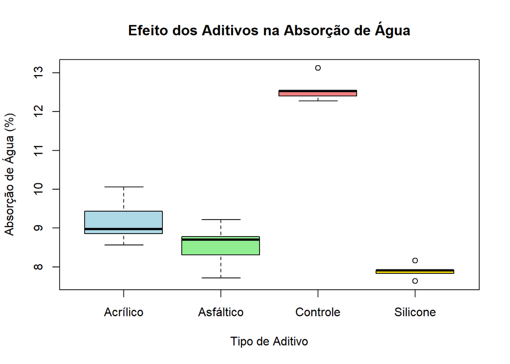

```r
# Boxplot
boxplot(absorcao ~ aditivo, data = experimento,
        col = c("lightblue", "lightgreen", "lightcoral", "gold"),
        main = "Efeito dos Aditivos na Absorção de Água",
        xlab = "Tipo de Aditivo", ylab = "Absorção de Água (%)")
```

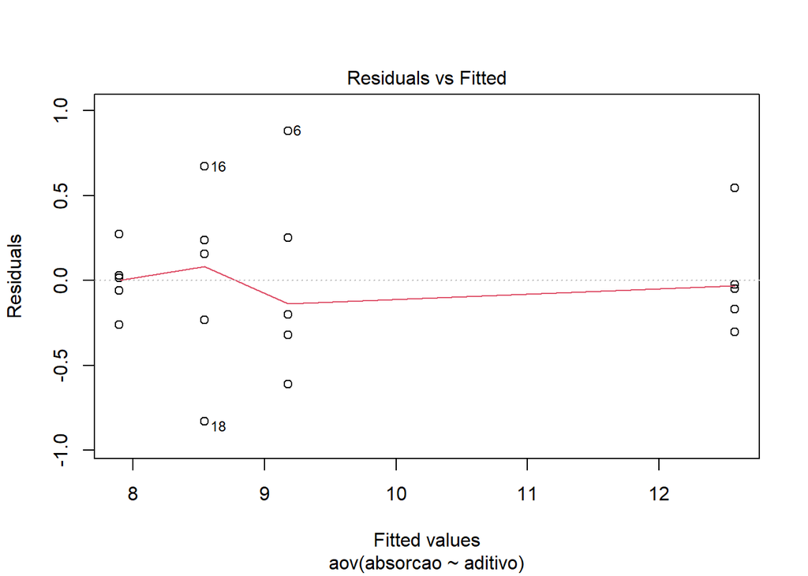

```r
# Gráfico de resíduos
plot(modelo, which = 1)  # Resíduos vs ajustados
```

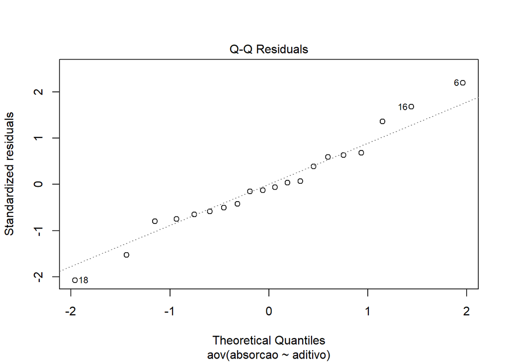

```r
plot(modelo, which = 2)  # QQ-plot dos resíduos
```

```r
# Teste de Tukey
tukey <- TukeyHSD(modelo)
print(tukey)
```

```
##   Tukey multiple comparisons of means
##     95% family-wise confidence level
##
## Fit: aov(formula = absorcao ~ aditivo, data = experimento)
##
## $aditivo
##                       diff     lwr        upr     p adj
## Asfáltico-Acrílico -0.6340 -1.4429  0.1749001 0.1540218
## Controle-Acrílico   3.3996  2.5907  4.2085001 0.0000000
## Silicone-Acrílico  -1.2856 -2.0945 -0.4766999 0.0016874
## Controle-Asfáltico  4.0336  3.2247  4.8425001 0.0000000
## Silicone-Asfáltico -0.6516 -1.4605  0.1573001 0.1384620
## Silicone-Controle  -4.6852 -5.4941 -3.8762999 0.0000000
```

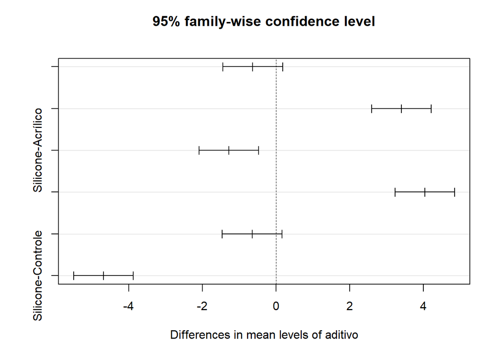

```r
# Gráfico do teste de Tukey
plot(tukey)
```

# 3 Conclusão

O experimento mostrou que há diferença significativa entre os tipos de aditivos impermeabilizantes em relação à absorção de água (%) dos blocos de concreto, conforme indicado pelo teste F da ANOVA. Os testes de pressupostos confirmaram a validade da análise (resíduos normais e variâncias homogêneas). O teste de Tukey indicou que o aditivo Silicone apresentou a menor absorção, significativamente diferente do grupo Controle, que apresentou os maiores valores. Portanto, o uso de aditivos impermeabilizantes — especialmente os do tipo Silicone — demonstrou-se eficaz na redução da absorção de água, contribuindo para a durabilidade dos blocos de concreto.